# Risk Factor Analysis

## Outcome Variable

**Outcome Variable:** ever_co

## Predictor Variables

**Intervention Variable:** hdlvry

**Adjustment Set:**

- arm
- sex
- W_mage
- meducyrs
- feducyrs
- hhwealth_quart
- single
- W_nrooms
- brthmon
- W_parity
- impsan
- delta_W_mage
- delta_meducyrs
- delta_feducyrs
- delta_hhwealth_quart
- delta_single
- delta_W_nrooms
- delta_brthmon
- delta_W_parity
- delta_impsan

## Stratifying Variables

The analysis was stratified on these variable(s):

- agecat
- studyid
- country

## Data Summary

| agecat | studyid | country | hdlvry | ever_co | n_cell | n |
| --- | --- | --- | --- | --- | --- | --- |
| 0-24 months | ki1000108-CMC-V-BCS-2002 | INDIA | 0 | 0 | 279 | 370 |
| 0-24 months | ki1000108-CMC-V-BCS-2002 | INDIA | 0 | 1 | 83 | 370 |
| 0-24 months | ki1000108-CMC-V-BCS-2002 | INDIA | 1 | 0 | 7 | 370 |
| 0-24 months | ki1000108-CMC-V-BCS-2002 | INDIA | 1 | 1 | 1 | 370 |
| 0-24 months | ki1000108-IRC | INDIA | 0 | 0 | 328 | 410 |
| 0-24 months | ki1000108-IRC | INDIA | 0 | 1 | 74 | 410 |
| 0-24 months | ki1000108-IRC | INDIA | 1 | 0 | 6 | 410 |
| 0-24 months | ki1000108-IRC | INDIA | 1 | 1 | 2 | 410 |
| 0-24 months | ki1000109-EE | PAKISTAN | 0 | 0 | 143 | 377 |
| 0-24 months | ki1000109-EE | PAKISTAN | 0 | 1 | 110 | 377 |
| 0-24 months | ki1000109-EE | PAKISTAN | 1 | 0 | 65 | 377 |
| 0-24 months | ki1000109-EE | PAKISTAN | 1 | 1 | 59 | 377 |
| 0-24 months | ki1000304b-SAS-CompFeed | INDIA | 0 | 0 | 140 | 1232 |
| 0-24 months | ki1000304b-SAS-CompFeed | INDIA | 0 | 1 | 24 | 1232 |
| 0-24 months | ki1000304b-SAS-CompFeed | INDIA | 1 | 0 | 795 | 1232 |
| 0-24 months | ki1000304b-SAS-CompFeed | INDIA | 1 | 1 | 273 | 1232 |
| 0-24 months | ki1000304b-SAS-FoodSuppl | INDIA | 0 | 0 | 55 | 418 |
| 0-24 months | ki1000304b-SAS-FoodSuppl | INDIA | 0 | 1 | 26 | 418 |
| 0-24 months | ki1000304b-SAS-FoodSuppl | INDIA | 1 | 0 | 208 | 418 |
| 0-24 months | ki1000304b-SAS-FoodSuppl | INDIA | 1 | 1 | 129 | 418 |
| 0-24 months | ki1017093b-PROVIDE | BANGLADESH | 0 | 0 | 456 | 700 |
| 0-24 months | ki1017093b-PROVIDE | BANGLADESH | 0 | 1 | 63 | 700 |
| 0-24 months | ki1017093b-PROVIDE | BANGLADESH | 1 | 0 | 154 | 700 |
| 0-24 months | ki1017093b-PROVIDE | BANGLADESH | 1 | 1 | 27 | 700 |
| 0-24 months | ki1017093c-NIH-Crypto | BANGLADESH | 0 | 0 | 545 | 758 |
| 0-24 months | ki1017093c-NIH-Crypto | BANGLADESH | 0 | 1 | 45 | 758 |
| 0-24 months | ki1017093c-NIH-Crypto | BANGLADESH | 1 | 0 | 142 | 758 |
| 0-24 months | ki1017093c-NIH-Crypto | BANGLADESH | 1 | 1 | 26 | 758 |
| 0-24 months | ki1066203-TanzaniaChild2 | TANZANIA, UNITED REPUBLIC OF | 0 | 0 | 2121 | 2274 |
| 0-24 months | ki1066203-TanzaniaChild2 | TANZANIA, UNITED REPUBLIC OF | 0 | 1 | 113 | 2274 |

[output cut: 114 more lines]

The following strata were considered:

- agecat: 0-24 months, studyid: ki1000108-CMC-V-BCS-2002, country: INDIA
- agecat: 0-24 months, studyid: ki1000108-IRC, country: INDIA
- agecat: 0-24 months, studyid: ki1000109-EE, country: PAKISTAN
- agecat: 0-24 months, studyid: ki1000304b-SAS-CompFeed, country: INDIA
- agecat: 0-24 months, studyid: ki1000304b-SAS-FoodSuppl, country: INDIA
- agecat: 0-24 months, studyid: ki1017093b-PROVIDE, country: BANGLADESH
- agecat: 0-24 months, studyid: ki1017093c-NIH-Crypto, country: BANGLADESH
- agecat: 0-24 months, studyid: ki1066203-TanzaniaChild2, country: TANZANIA, UNITED REPUBLIC OF
- agecat: 0-24 months, studyid: ki1113344-GMS-Nepal, country: NEPAL
- agecat: 0-24 months, studyid: ki1135781-COHORTS, country: INDIA
- agecat: 0-24 months, studyid: kiGH5241-JiVitA-3, country: BANGLADESH
- agecat: 0-24 months, studyid: kiGH5241-JiVitA-4, country: BANGLADESH
- agecat: 0-6 months, studyid: ki1000108-CMC-V-BCS-2002, country: INDIA
- agecat: 0-6 months, studyid: ki1000108-IRC, country: INDIA
- agecat: 0-6 months, studyid: ki1000109-EE, country: PAKISTAN
- agecat: 0-6 months, studyid: ki1000304b-SAS-CompFeed, country: INDIA
- agecat: 0-6 months, studyid: ki1000304b-SAS-FoodSuppl, country: INDIA
- agecat: 0-6 months, studyid: ki1017093b-PROVIDE, country: BANGLADESH
- agecat: 0-6 months, studyid: ki1017093c-NIH-Crypto, country: BANGLADESH
- agecat: 0-6 months, studyid: ki1066203-TanzaniaChild2, country: TANZANIA, UNITED REPUBLIC OF
- agecat: 0-6 months, studyid: ki1113344-GMS-Nepal, country: NEPAL
- agecat: 0-6 months, studyid: ki1135781-COHORTS, country: INDIA
- agecat: 0-6 months, studyid: kiGH5241-JiVitA-3, country: BANGLADESH
- agecat: 0-6 months, studyid: kiGH5241-JiVitA-4, country: BANGLADESH
- agecat: 6-24 months, studyid: ki1000108-CMC-V-BCS-2002, country: INDIA
- agecat: 6-24 months, studyid: ki1000108-IRC, country: INDIA
- agecat: 6-24 months, studyid: ki1000109-EE, country: PAKISTAN
- agecat: 6-24 months, studyid: ki1000304b-SAS-CompFeed, country: INDIA
- agecat: 6-24 months, studyid: ki1000304b-SAS-FoodSuppl, country: INDIA
- agecat: 6-24 months, studyid: ki1017093b-PROVIDE, country: BANGLADESH
- agecat: 6-24 months, studyid: ki1017093c-NIH-Crypto, country: BANGLADESH
- agecat: 6-24 months, studyid: ki1066203-TanzaniaChild2, country: TANZANIA, UNITED REPUBLIC OF
- agecat: 6-24 months, studyid: ki1113344-GMS-Nepal, country: NEPAL
- agecat: 6-24 months, studyid: ki1135781-COHORTS, country: INDIA
- agecat: 6-24 months, studyid: kiGH5241-JiVitA-3, country: BANGLADESH
- agecat: 6-24 months, studyid: kiGH5241-JiVitA-4, country: BANGLADESH

### Dropped Strata

Some strata were dropped due to rare outcomes:

- agecat: 0-24 months, studyid: ki1000108-CMC-V-BCS-2002, country: INDIA
- agecat: 0-24 months, studyid: ki1000108-IRC, country: INDIA
- agecat: 0-24 months, studyid: ki1066203-TanzaniaChild2, country: TANZANIA, UNITED REPUBLIC OF
- agecat: 0-24 months, studyid: kiGH5241-JiVitA-3, country: BANGLADESH
- agecat: 0-6 months, studyid: ki1000108-CMC-V-BCS-2002, country: INDIA
- agecat: 0-6 months, studyid: ki1000108-IRC, country: INDIA
- agecat: 0-6 months, studyid: ki1000304b-SAS-CompFeed, country: INDIA
- agecat: 0-6 months, studyid: ki1000304b-SAS-FoodSuppl, country: INDIA
- agecat: 0-6 months, studyid: ki1066203-TanzaniaChild2, country: TANZANIA, UNITED REPUBLIC OF
- agecat: 0-6 months, studyid: kiGH5241-JiVitA-3, country: BANGLADESH
- agecat: 6-24 months, studyid: ki1000108-CMC-V-BCS-2002, country: INDIA
- agecat: 6-24 months, studyid: ki1000108-IRC, country: INDIA
- agecat: 6-24 months, studyid: ki1066203-TanzaniaChild2, country: TANZANIA, UNITED REPUBLIC OF
- agecat: 6-24 months, studyid: kiGH5241-JiVitA-3, country: BANGLADESH

## Methods Detail

We’re interested in the causal parameters $E[Y_a]$ for all values of $a \in \mathcal{A}$. These parameters represent the mean outcome if, possibly contrary to fact, we intervened to set all units to have $A=a$. Under the randomization and positivity assumptions, these are identified by the statistical parameters $\psi_a=E_W[E_{Y|A,W}(Y|A=a,W)]$. In addition, we’re interested in the mean of $Y$, $E[Y]$ under no intervention (the observed mean). We will estimate these parameters by using SuperLearner to fit the relevant likelihood factors – $E_{Y|A,W}(Y|A=a,W)$ and $p(A=a|W)$, and then updating our likelihood fit using a joint TMLE.

For unadjusted analyses ($W=\{\}$), initial likelihoods were estimated using Lrnr_glm to estimate the simple $E(Y|A)$ and Lrnr_mean to estimate $p(A)$. For adjusted analyses, a small library containing Lrnr_glmnet, Lrnr_xgboost, and Lrnr_mean was used.

Having estimated these parameters, we will then use the delta method to estimate relative risks and attributable risks relative to a prespecified baseline level of $A$.

# Results Detail

## Results Plots

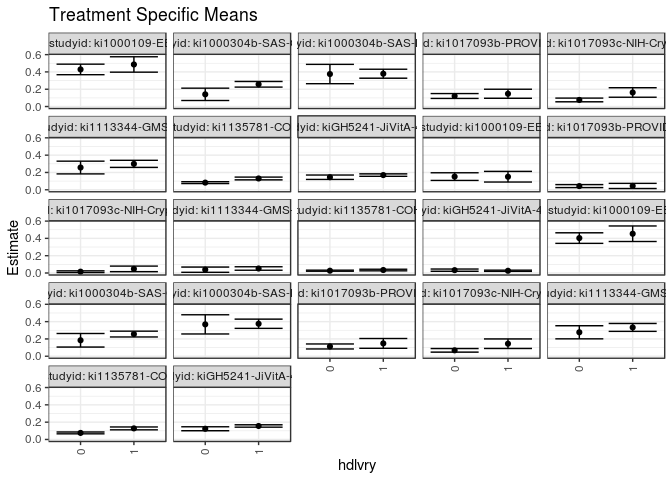

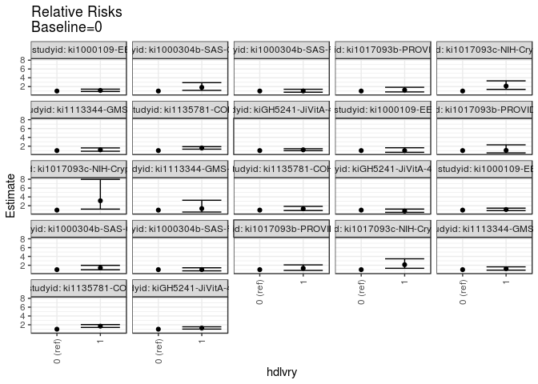

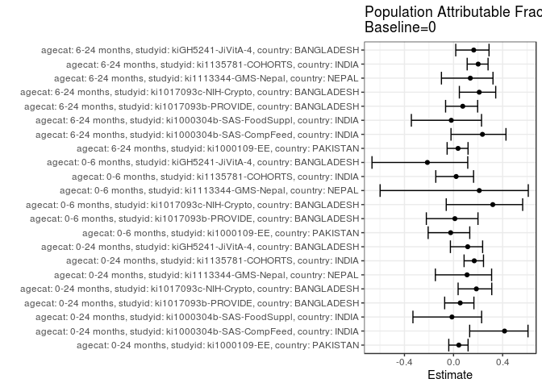

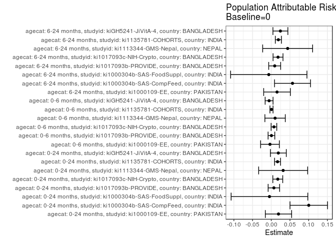

## Results Table

### Parameter: TSM

| agecat | studyid | country | intervention_level | baseline_level | estimate | ci_lower | ci_upper |
| --- | --- | --- | --- | --- | --- | --- | --- |
| 0-24 months | ki1000109-EE | PAKISTAN | 0 | NA | 0.4289645 | 0.3681023 | 0.4898267 |
| 0-24 months | ki1000109-EE | PAKISTAN | 1 | NA | 0.4861589 | 0.3972036 | 0.5751142 |
| 0-24 months | ki1000304b-SAS-CompFeed | INDIA | 0 | NA | 0.1408475 | 0.0696116 | 0.2120834 |
| 0-24 months | ki1000304b-SAS-CompFeed | INDIA | 1 | NA | 0.2571950 | 0.2245968 | 0.2897932 |
| 0-24 months | ki1000304b-SAS-FoodSuppl | INDIA | 0 | NA | 0.3756390 | 0.2640873 | 0.4871907 |
| 0-24 months | ki1000304b-SAS-FoodSuppl | INDIA | 1 | NA | 0.3793216 | 0.3273856 | 0.4312576 |
| 0-24 months | ki1017093b-PROVIDE | BANGLADESH | 0 | NA | 0.1215824 | 0.0934377 | 0.1497270 |
| 0-24 months | ki1017093b-PROVIDE | BANGLADESH | 1 | NA | 0.1477221 | 0.0955504 | 0.1998938 |
| 0-24 months | ki1017093c-NIH-Crypto | BANGLADESH | 0 | NA | 0.0762542 | 0.0548314 | 0.0976771 |
| 0-24 months | ki1017093c-NIH-Crypto | BANGLADESH | 1 | NA | 0.1622765 | 0.1073887 | 0.2171643 |
| 0-24 months | ki1113344-GMS-Nepal | NEPAL | 0 | NA | 0.2570358 | 0.1835996 | 0.3304720 |
| 0-24 months | ki1113344-GMS-Nepal | NEPAL | 1 | NA | 0.2994565 | 0.2583748 | 0.3405382 |
| 0-24 months | ki1135781-COHORTS | INDIA | 0 | NA | 0.0826470 | 0.0721268 | 0.0931672 |
| 0-24 months | ki1135781-COHORTS | INDIA | 1 | NA | 0.1305027 | 0.1143818 | 0.1466236 |
| 0-24 months | kiGH5241-JiVitA-4 | BANGLADESH | 0 | NA | 0.1448350 | 0.1193912 | 0.1702789 |
| 0-24 months | kiGH5241-JiVitA-4 | BANGLADESH | 1 | NA | 0.1697652 | 0.1556887 | 0.1838416 |
| 0-6 months | ki1000109-EE | PAKISTAN | 0 | NA | 0.1520247 | 0.1077845 | 0.1962648 |
| 0-6 months | ki1000109-EE | PAKISTAN | 1 | NA | 0.1506719 | 0.0892007 | 0.2121431 |
| 0-6 months | ki1017093b-PROVIDE | BANGLADESH | 0 | NA | 0.0423892 | 0.0250433 | 0.0597351 |
| 0-6 months | ki1017093b-PROVIDE | BANGLADESH | 1 | NA | 0.0441989 | 0.0142343 | 0.0741635 |
| 0-6 months | ki1017093c-NIH-Crypto | BANGLADESH | 0 | NA | 0.0152542 | 0.0053581 | 0.0251504 |
| 0-6 months | ki1017093c-NIH-Crypto | BANGLADESH | 1 | NA | 0.0476190 | 0.0153953 | 0.0798428 |
| 0-6 months | ki1113344-GMS-Nepal | NEPAL | 0 | NA | 0.0384615 | 0.0082604 | 0.0686627 |
| 0-6 months | ki1113344-GMS-Nepal | NEPAL | 1 | NA | 0.0519751 | 0.0321221 | 0.0718280 |
| 0-6 months | ki1135781-COHORTS | INDIA | 0 | NA | 0.0266060 | 0.0204690 | 0.0327430 |
| 0-6 months | ki1135781-COHORTS | INDIA | 1 | NA | 0.0344785 | 0.0252606 | 0.0436964 |
| 0-6 months | kiGH5241-JiVitA-4 | BANGLADESH | 0 | NA | 0.0329417 | 0.0200535 | 0.0458300 |
| 0-6 months | kiGH5241-JiVitA-4 | BANGLADESH | 1 | NA | 0.0257779 | 0.0189102 | 0.0326457 |
| 6-24 months | ki1000109-EE | PAKISTAN | 0 | NA | 0.4035103 | 0.3425210 | 0.4644996 |
| 6-24 months | ki1000109-EE | PAKISTAN | 1 | NA | 0.4537097 | 0.3638083 | 0.5436110 |
| 6-24 months | ki1000304b-SAS-CompFeed | INDIA | 0 | NA | 0.1843486 | 0.1059489 | 0.2627482 |
| 6-24 months | ki1000304b-SAS-CompFeed | INDIA | 1 | NA | 0.2562194 | 0.2228711 | 0.2895678 |
| 6-24 months | ki1000304b-SAS-FoodSuppl | INDIA | 0 | NA | 0.3682653 | 0.2574037 | 0.4791269 |
| 6-24 months | ki1000304b-SAS-FoodSuppl | INDIA | 1 | NA | 0.3753389 | 0.3220429 | 0.4286350 |
| 6-24 months | ki1017093b-PROVIDE | BANGLADESH | 0 | NA | 0.1129792 | 0.0839770 | 0.1419815 |
| 6-24 months | ki1017093b-PROVIDE | BANGLADESH | 1 | NA | 0.1482782 | 0.0915187 | 0.2050378 |
| 6-24 months | ki1017093c-NIH-Crypto | BANGLADESH | 0 | NA | 0.0682356 | 0.0473882 | 0.0890830 |
| 6-24 months | ki1017093c-NIH-Crypto | BANGLADESH | 1 | NA | 0.1449233 | 0.0898482 | 0.1999984 |
| 6-24 months | ki1113344-GMS-Nepal | NEPAL | 0 | NA | 0.2767636 | 0.2011621 | 0.3523651 |
| 6-24 months | ki1113344-GMS-Nepal | NEPAL | 1 | NA | 0.3329766 | 0.2874167 | 0.3785365 |
| 6-24 months | ki1135781-COHORTS | INDIA | 0 | NA | 0.0757071 | 0.0651432 | 0.0862710 |
| 6-24 months | ki1135781-COHORTS | INDIA | 1 | NA | 0.1279924 | 0.1113569 | 0.1446280 |
| 6-24 months | kiGH5241-JiVitA-4 | BANGLADESH | 0 | NA | 0.1238554 | 0.1009179 | 0.1467929 |
| 6-24 months | kiGH5241-JiVitA-4 | BANGLADESH | 1 | NA | 0.1557444 | 0.1419434 | 0.1695454 |

### Parameter: E(Y)

| agecat | studyid | country | intervention_level | baseline_level | estimate | ci_lower | ci_upper |
| --- | --- | --- | --- | --- | --- | --- | --- |
| 0-24 months | ki1000109-EE | PAKISTAN | NA | NA | 0.4482759 | 0.3980083 | 0.4985434 |
| 0-24 months | ki1000304b-SAS-CompFeed | INDIA | NA | NA | 0.2410714 | 0.1975050 | 0.2846379 |
| 0-24 months | ki1000304b-SAS-FoodSuppl | INDIA | NA | NA | 0.3708134 | 0.3244530 | 0.4171738 |
| 0-24 months | ki1017093b-PROVIDE | BANGLADESH | NA | NA | 0.1285714 | 0.1037574 | 0.1533855 |
| 0-24 months | ki1017093c-NIH-Crypto | BANGLADESH | NA | NA | 0.0936675 | 0.0729118 | 0.1144233 |
| 0-24 months | ki1113344-GMS-Nepal | NEPAL | NA | NA | 0.2888540 | 0.2536300 | 0.3240780 |
| 0-24 months | ki1135781-COHORTS | INDIA | NA | NA | 0.0994301 | 0.0912079 | 0.1076524 |
| 0-24 months | kiGH5241-JiVitA-4 | BANGLADESH | NA | NA | 0.1637414 | 0.1510998 | 0.1763830 |
| 0-6 months | ki1000109-EE | PAKISTAN | NA | NA | 0.1485411 | 0.1125944 | 0.1844878 |
| 0-6 months | ki1017093b-PROVIDE | BANGLADESH | NA | NA | 0.0428571 | 0.0278427 | 0.0578716 |
| 0-6 months | ki1017093c-NIH-Crypto | BANGLADESH | NA | NA | 0.0224274 | 0.0118796 | 0.0329753 |
| 0-6 months | ki1113344-GMS-Nepal | NEPAL | NA | NA | 0.0486656 | 0.0319433 | 0.0653880 |
| 0-6 months | ki1135781-COHORTS | INDIA | NA | NA | 0.0271860 | 0.0226456 | 0.0317265 |
| 0-6 months | kiGH5241-JiVitA-4 | BANGLADESH | NA | NA | 0.0271544 | 0.0212424 | 0.0330664 |
| 6-24 months | ki1000109-EE | PAKISTAN | NA | NA | 0.4189189 | 0.3685783 | 0.4692595 |
| 6-24 months | ki1000304b-SAS-CompFeed | INDIA | NA | NA | 0.2411348 | 0.1953341 | 0.2869354 |
| 6-24 months | ki1000304b-SAS-FoodSuppl | INDIA | NA | NA | 0.3615960 | 0.3145115 | 0.4086805 |
| 6-24 months | ki1017093b-PROVIDE | BANGLADESH | NA | NA | 0.1221498 | 0.0962275 | 0.1480722 |
| 6-24 months | ki1017093c-NIH-Crypto | BANGLADESH | NA | NA | 0.0863014 | 0.0659171 | 0.1066856 |
| 6-24 months | ki1113344-GMS-Nepal | NEPAL | NA | NA | 0.3205829 | 0.2815081 | 0.3596576 |
| 6-24 months | ki1135781-COHORTS | INDIA | NA | NA | 0.0947257 | 0.0863884 | 0.1030631 |
| 6-24 months | kiGH5241-JiVitA-4 | BANGLADESH | NA | NA | 0.1482636 | 0.1364361 | 0.1600910 |

### Parameter: RR

| agecat | studyid | country | intervention_level | baseline_level | estimate | ci_lower | ci_upper |
| --- | --- | --- | --- | --- | --- | --- | --- |
| 0-24 months | ki1000109-EE | PAKISTAN | 0 | 0 | 1.0000000 | 1.0000000 | 1.000000 |
| 0-24 months | ki1000109-EE | PAKISTAN | 1 | 0 | 1.1333313 | 0.8998880 | 1.427333 |
| 0-24 months | ki1000304b-SAS-CompFeed | INDIA | 0 | 0 | 1.0000000 | 1.0000000 | 1.000000 |
| 0-24 months | ki1000304b-SAS-CompFeed | INDIA | 1 | 0 | 1.8260524 | 1.1480311 | 2.904510 |
| 0-24 months | ki1000304b-SAS-FoodSuppl | INDIA | 0 | 0 | 1.0000000 | 1.0000000 | 1.000000 |
| 0-24 months | ki1000304b-SAS-FoodSuppl | INDIA | 1 | 0 | 1.0098036 | 0.7288438 | 1.399070 |
| 0-24 months | ki1017093b-PROVIDE | BANGLADESH | 0 | 0 | 1.0000000 | 1.0000000 | 1.000000 |
| 0-24 months | ki1017093b-PROVIDE | BANGLADESH | 1 | 0 | 1.2149961 | 0.7969839 | 1.852253 |
| 0-24 months | ki1017093c-NIH-Crypto | BANGLADESH | 0 | 0 | 1.0000000 | 1.0000000 | 1.000000 |
| 0-24 months | ki1017093c-NIH-Crypto | BANGLADESH | 1 | 0 | 2.1280980 | 1.3697083 | 3.306398 |
| 0-24 months | ki1113344-GMS-Nepal | NEPAL | 0 | 0 | 1.0000000 | 1.0000000 | 1.000000 |
| 0-24 months | ki1113344-GMS-Nepal | NEPAL | 1 | 0 | 1.1650381 | 0.8486136 | 1.599449 |
| 0-24 months | ki1135781-COHORTS | INDIA | 0 | 0 | 1.0000000 | 1.0000000 | 1.000000 |
| 0-24 months | ki1135781-COHORTS | INDIA | 1 | 0 | 1.5790374 | 1.3231304 | 1.884439 |
| 0-24 months | kiGH5241-JiVitA-4 | BANGLADESH | 0 | 0 | 1.0000000 | 1.0000000 | 1.000000 |
| 0-24 months | kiGH5241-JiVitA-4 | BANGLADESH | 1 | 0 | 1.1721279 | 0.9694037 | 1.417246 |
| 0-6 months | ki1000109-EE | PAKISTAN | 0 | 0 | 1.0000000 | 1.0000000 | 1.000000 |
| 0-6 months | ki1000109-EE | PAKISTAN | 1 | 0 | 0.9911020 | 0.6017884 | 1.632273 |
| 0-6 months | ki1017093b-PROVIDE | BANGLADESH | 0 | 0 | 1.0000000 | 1.0000000 | 1.000000 |
| 0-6 months | ki1017093b-PROVIDE | BANGLADESH | 1 | 0 | 1.0426921 | 0.4723343 | 2.301774 |
| 0-6 months | ki1017093c-NIH-Crypto | BANGLADESH | 0 | 0 | 1.0000000 | 1.0000000 | 1.000000 |
| 0-6 months | ki1017093c-NIH-Crypto | BANGLADESH | 1 | 0 | 3.1216931 | 1.2225460 | 7.971044 |
| 0-6 months | ki1113344-GMS-Nepal | NEPAL | 0 | 0 | 1.0000000 | 1.0000000 | 1.000000 |
| 0-6 months | ki1113344-GMS-Nepal | NEPAL | 1 | 0 | 1.3513514 | 0.5643390 | 3.235910 |
| 0-6 months | ki1135781-COHORTS | INDIA | 0 | 0 | 1.0000000 | 1.0000000 | 1.000000 |
| 0-6 months | ki1135781-COHORTS | INDIA | 1 | 0 | 1.2958923 | 0.9103002 | 1.844817 |
| 0-6 months | kiGH5241-JiVitA-4 | BANGLADESH | 0 | 0 | 1.0000000 | 1.0000000 | 1.000000 |
| 0-6 months | kiGH5241-JiVitA-4 | BANGLADESH | 1 | 0 | 0.7825311 | 0.4946622 | 1.237925 |
| 6-24 months | ki1000109-EE | PAKISTAN | 0 | 0 | 1.0000000 | 1.0000000 | 1.000000 |
| 6-24 months | ki1000109-EE | PAKISTAN | 1 | 0 | 1.1244066 | 0.8760643 | 1.443148 |
| 6-24 months | ki1000304b-SAS-CompFeed | INDIA | 0 | 0 | 1.0000000 | 1.0000000 | 1.000000 |
| 6-24 months | ki1000304b-SAS-CompFeed | INDIA | 1 | 0 | 1.3898640 | 0.9763260 | 1.978562 |
| 6-24 months | ki1000304b-SAS-FoodSuppl | INDIA | 0 | 0 | 1.0000000 | 1.0000000 | 1.000000 |
| 6-24 months | ki1000304b-SAS-FoodSuppl | INDIA | 1 | 0 | 1.0192081 | 0.7300702 | 1.422856 |
| 6-24 months | ki1017093b-PROVIDE | BANGLADESH | 0 | 0 | 1.0000000 | 1.0000000 | 1.000000 |
| 6-24 months | ki1017093b-PROVIDE | BANGLADESH | 1 | 0 | 1.3124381 | 0.8278755 | 2.080619 |
| 6-24 months | ki1017093c-NIH-Crypto | BANGLADESH | 0 | 0 | 1.0000000 | 1.0000000 | 1.000000 |
| 6-24 months | ki1017093c-NIH-Crypto | BANGLADESH | 1 | 0 | 2.1238674 | 1.3041327 | 3.458860 |
| 6-24 months | ki1113344-GMS-Nepal | NEPAL | 0 | 0 | 1.0000000 | 1.0000000 | 1.000000 |
| 6-24 months | ki1113344-GMS-Nepal | NEPAL | 1 | 0 | 1.2031083 | 0.8858576 | 1.633976 |
| 6-24 months | ki1135781-COHORTS | INDIA | 0 | 0 | 1.0000000 | 1.0000000 | 1.000000 |
| 6-24 months | ki1135781-COHORTS | INDIA | 1 | 0 | 1.6906262 | 1.3980740 | 2.044396 |
| 6-24 months | kiGH5241-JiVitA-4 | BANGLADESH | 0 | 0 | 1.0000000 | 1.0000000 | 1.000000 |
| 6-24 months | kiGH5241-JiVitA-4 | BANGLADESH | 1 | 0 | 1.2574694 | 1.0250523 | 1.542584 |

### Parameter: PAR

| agecat | studyid | country | intervention_level | baseline_level | estimate | ci_lower | ci_upper |
| --- | --- | --- | --- | --- | --- | --- | --- |
| 0-24 months | ki1000109-EE | PAKISTAN | 0 | NA | 0.0193114 | -0.0158818 | 0.0545046 |
| 0-24 months | ki1000304b-SAS-CompFeed | INDIA | 0 | NA | 0.1002239 | 0.0500719 | 0.1503759 |
| 0-24 months | ki1000304b-SAS-FoodSuppl | INDIA | 0 | NA | -0.0048256 | -0.1073272 | 0.0976760 |
| 0-24 months | ki1017093b-PROVIDE | BANGLADESH | 0 | NA | 0.0069891 | -0.0083359 | 0.0223140 |
| 0-24 months | ki1017093c-NIH-Crypto | BANGLADESH | 0 | NA | 0.0174133 | 0.0041470 | 0.0306796 |
| 0-24 months | ki1113344-GMS-Nepal | NEPAL | 0 | NA | 0.0318182 | -0.0337005 | 0.0973369 |
| 0-24 months | ki1135781-COHORTS | INDIA | 0 | NA | 0.0167831 | 0.0088329 | 0.0247334 |
| 0-24 months | kiGH5241-JiVitA-4 | BANGLADESH | 0 | NA | 0.0189064 | -0.0023702 | 0.0401829 |
| 0-6 months | ki1000109-EE | PAKISTAN | 0 | NA | -0.0034835 | -0.0285552 | 0.0215881 |
| 0-6 months | ki1017093b-PROVIDE | BANGLADESH | 0 | NA | 0.0004679 | -0.0084848 | 0.0094207 |
| 0-6 months | ki1017093c-NIH-Crypto | BANGLADESH | 0 | NA | 0.0071732 | -0.0003591 | 0.0147055 |
| 0-6 months | ki1113344-GMS-Nepal | NEPAL | 0 | NA | 0.0102041 | -0.0170906 | 0.0374988 |
| 0-6 months | ki1135781-COHORTS | INDIA | 0 | NA | 0.0005801 | -0.0035882 | 0.0047483 |
| 0-6 months | kiGH5241-JiVitA-4 | BANGLADESH | 0 | NA | -0.0057873 | -0.0163345 | 0.0047598 |
| 6-24 months | ki1000109-EE | PAKISTAN | 0 | NA | 0.0154086 | -0.0202486 | 0.0510659 |
| 6-24 months | ki1000304b-SAS-CompFeed | INDIA | 0 | NA | 0.0567862 | 0.0087036 | 0.1048688 |
| 6-24 months | ki1000304b-SAS-FoodSuppl | INDIA | 0 | NA | -0.0066693 | -0.1087056 | 0.0953670 |
| 6-24 months | ki1017093b-PROVIDE | BANGLADESH | 0 | NA | 0.0091706 | -0.0068170 | 0.0251583 |
| 6-24 months | ki1017093c-NIH-Crypto | BANGLADESH | 0 | NA | 0.0180658 | 0.0047906 | 0.0313410 |
| 6-24 months | ki1113344-GMS-Nepal | NEPAL | 0 | NA | 0.0438193 | -0.0229281 | 0.1105667 |
| 6-24 months | ki1135781-COHORTS | INDIA | 0 | NA | 0.0190186 | 0.0108349 | 0.0272024 |
| 6-24 months | kiGH5241-JiVitA-4 | BANGLADESH | 0 | NA | 0.0244082 | 0.0044344 | 0.0443820 |

### Parameter: PAF

| agecat | studyid | country | intervention_level | baseline_level | estimate | ci_lower | ci_upper |
| --- | --- | --- | --- | --- | --- | --- | --- |
| 0-24 months | ki1000109-EE | PAKISTAN | 0 | NA | 0.0430792 | -0.0388097 | 0.1185129 |
| 0-24 months | ki1000304b-SAS-CompFeed | INDIA | 0 | NA | 0.4157436 | 0.1314683 | 0.6069740 |
| 0-24 months | ki1000304b-SAS-FoodSuppl | INDIA | 0 | NA | -0.0130136 | -0.3308834 | 0.2289358 |
| 0-24 months | ki1017093b-PROVIDE | BANGLADESH | 0 | NA | 0.0543594 | -0.0722808 | 0.1660430 |
| 0-24 months | ki1017093c-NIH-Crypto | BANGLADESH | 0 | NA | 0.1859054 | 0.0373319 | 0.3115488 |
| 0-24 months | ki1113344-GMS-Nepal | NEPAL | 0 | NA | 0.1101532 | -0.1481848 | 0.3103660 |
| 0-24 months | ki1135781-COHORTS | INDIA | 0 | NA | 0.1687933 | 0.0858946 | 0.2441741 |
| 0-24 months | kiGH5241-JiVitA-4 | BANGLADESH | 0 | NA | 0.1154649 | -0.0255251 | 0.2370715 |
| 0-6 months | ki1000109-EE | PAKISTAN | 0 | NA | -0.0234517 | -0.2069304 | 0.1321344 |
| 0-6 months | ki1017093b-PROVIDE | BANGLADESH | 0 | NA | 0.0109184 | -0.2216378 | 0.1992043 |
| 0-6 months | ki1017093c-NIH-Crypto | BANGLADESH | 0 | NA | 0.3198405 | -0.0594838 | 0.5633562 |
| 0-6 months | ki1113344-GMS-Nepal | NEPAL | 0 | NA | 0.2096774 | -0.5983068 | 0.6092053 |
| 0-6 months | ki1135781-COHORTS | INDIA | 0 | NA | 0.0213367 | -0.1446630 | 0.1632630 |
| 0-6 months | kiGH5241-JiVitA-4 | BANGLADESH | 0 | NA | -0.2131270 | -0.6645105 | 0.1158499 |
| 6-24 months | ki1000109-EE | PAKISTAN | 0 | NA | 0.0367819 | -0.0522193 | 0.1182550 |
| 6-24 months | ki1000304b-SAS-CompFeed | INDIA | 0 | NA | 0.2354957 | -0.0206254 | 0.4273444 |
| 6-24 months | ki1000304b-SAS-FoodSuppl | INDIA | 0 | NA | -0.0184440 | -0.3437199 | 0.2280920 |
| 6-24 months | ki1017093b-PROVIDE | BANGLADESH | 0 | NA | 0.0750769 | -0.0647234 | 0.1965211 |
| 6-24 months | ki1017093c-NIH-Crypto | BANGLADESH | 0 | NA | 0.2093341 | 0.0474493 | 0.3437067 |
| 6-24 months | ki1113344-GMS-Nepal | NEPAL | 0 | NA | 0.1366863 | -0.0985380 | 0.3215432 |
| 6-24 months | ki1135781-COHORTS | INDIA | 0 | NA | 0.2007758 | 0.1111281 | 0.2813820 |
| 6-24 months | kiGH5241-JiVitA-4 | BANGLADESH | 0 | NA | 0.1646269 | 0.0181010 | 0.2892872 |